# Analysis with Missing Data

Is the slope of the relationship between hedonic values & consumer intentions stronger in any one of the framing conditions compared to the others?

```r
emtrends(full_model_1a, pairwise~framing_condition, var = "hedonic_center", adjust = "none")
```

```
## $emtrends
##  framing_condition hedonic_center.trend     SE  df lower.CL upper.CL
##  control_framing                -0.0845 0.0968 883   -0.275    0.106
##  pro_env_framing                -0.0171 0.0972 883   -0.208    0.174
##  self_enh_framing               -0.1961 0.1050 883   -0.402    0.010
##
## Results are averaged over the levels of: norm_condition, Gender
## Confidence level used: 0.95
##
## $contrasts
##  contrast                           estimate    SE  df t.ratio p.value
##  control_framing - pro_env_framing   -0.0674 0.137 883  -0.491  0.6232
##  control_framing - self_enh_framing   0.1117 0.143 883   0.783  0.4341
##  pro_env_framing - self_enh_framing   0.1791 0.143 883   1.252  0.2110
##
## Results are averaged over the levels of: norm_condition, Gender
```

Third, interaction between hedonic values, framing, & norm condition:

```r
emtrends(full_model_1a, ~norm_condition | framing_condition, var = "hedonic_center", adjust = "none")
```

```
## framing_condition = control_framing:
##  norm_condition   hedonic_center.trend    SE  df lower.CL upper.CL
##  control_norm                 -0.32372 0.192 883   -0.701   0.0533
##  descriptive_norm              0.11191 0.247 883   -0.374   0.5973
##  convention_norm               0.12891 0.218 883   -0.299   0.5568
##  social_norm                   0.00908 0.194 883   -0.372   0.3898
##  moral_norm                   -0.34847 0.227 883   -0.793   0.0963
##
## framing_condition = pro_env_framing:
##  norm_condition   hedonic_center.trend    SE  df lower.CL upper.CL
##  control_norm                  0.18116 0.223 883   -0.256   0.6183
##  descriptive_norm             -0.18693 0.227 883   -0.632   0.2579
##  convention_norm               0.23879 0.215 883   -0.184   0.6617
##  social_norm                  -0.21359 0.219 883   -0.643   0.2156
##  moral_norm                   -0.10469 0.202 883   -0.502   0.2925
##
## framing_condition = self_enh_framing:
##  norm_condition   hedonic_center.trend    SE  df lower.CL upper.CL
##  control_norm                 -0.23010 0.262 883   -0.745   0.2850
##  descriptive_norm              0.05794 0.252 883   -0.437   0.5526
##  convention_norm               0.13425 0.182 883   -0.224   0.4922
##  social_norm                  -0.41458 0.264 883   -0.933   0.1042
##  moral_norm                   -0.52822 0.202 883   -0.924  -0.1326
##
## Results are averaged over the levels of: Gender
## Confidence level used: 0.95
```

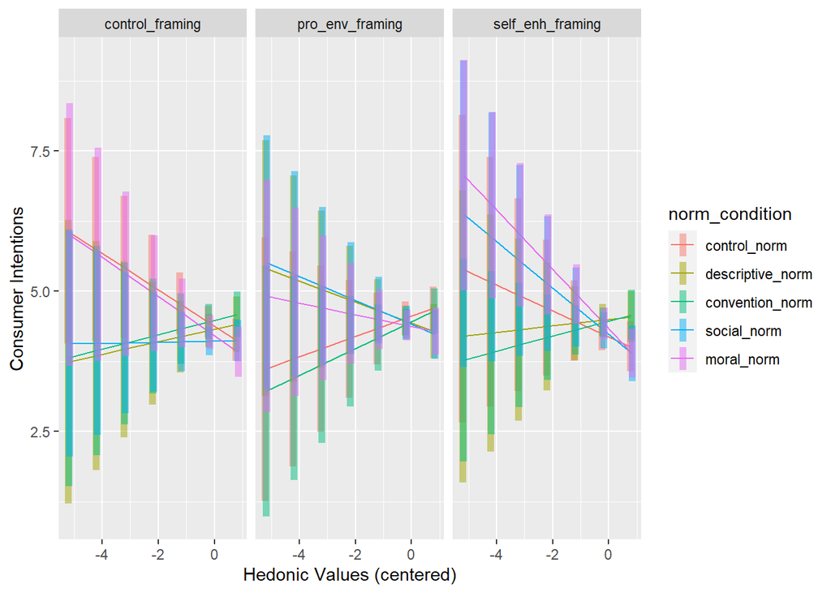

```r
# Separate graph for each framing condition
at_list <- list(hedonic_center = seq(-5.2, 1.2, by = 1))

emmip(full_model_1a, norm_condition ~ hedonic_center | framing_condition, at = at_list, CIs = TRUE, xlab = "Hedonic Values (centered)", ylab = "Consumer Intentions")
```

- In the control framing condition, hedonic values were not significantly related to consumer intentions in any norm condition.
- In the pro-environmental framing condition, hedonic values were not significantly related to consumer intentions in any norm condition.
- In the self-enhancing framing condition, hedonic values were not significantly related to consumer intentions in any norm condition except for the moral norm condition in which they were significantly, related related.

### Ingroup Identification Interactions

> > H5: There will be a two-way interaction between ingroup identification and norm condition.

In the overall analysis, there was no significant two-way interaction between ingroup identification & framing condition or between ingroup identification & norm condition.

First, relationship between ingroup identification & consumer intentions for each norm condition:

```r
emtrends(full_model_1a, ~norm_condition, var = "ingroup_identification_center", adjust = "none")
```

```
##  norm_condition   ingroup_identification_center.trend     SE  df lower.CL
##  control_norm                                  0.0338 0.0776 883  -0.1186
##  descriptive_norm                              0.0738 0.0836 883  -0.0903
##  convention_norm                               0.0393 0.0850 883  -0.1276
##  social_norm                                   0.0643 0.0781 883  -0.0890
##  moral_norm                                   -0.0502 0.0808 883  -0.2087
##  upper.CL
##     0.186
##     0.238
##     0.206
##     0.218
##     0.108
##
## Results are averaged over the levels of: framing_condition, Gender
## Confidence level used: 0.95
```

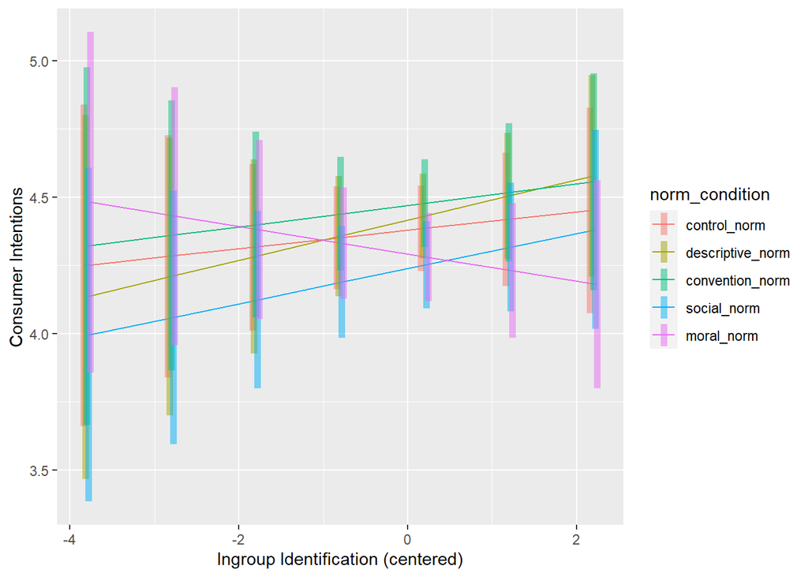

```r
# On a single graph
at_list <- list(ingroup_identification_center = seq(-3.8, 2.6, by = 1))

emmip(full_model_1a, norm_condition ~ ingroup_identification_center, at = at_list, CIs = TRUE, xlab = "Ingroup Identification (centered)", ylab = "Consumer Intentions")
```

- Ingroup identification was not significantly related to consumer intentions in any of the norm conditions.

Is the slope of the relationship between ingroup idenitification & consumer intentions stronger in any one of the norm conditions compared to the others?

```r
emtrends(full_model_1a, pairwise~norm_condition, var = "ingroup_identification_center", adjust = "none")
```

```
## $emtrends
##  norm_condition   ingroup_identification_center.trend     SE  df lower.CL
##  control_norm                                  0.0338 0.0776 883  -0.1186
##  descriptive_norm                              0.0738 0.0836 883  -0.0903
##  convention_norm                               0.0393 0.0850 883  -0.1276
##  social_norm                                   0.0643 0.0781 883  -0.0890
##  moral_norm                                   -0.0502 0.0808 883  -0.2087
##  upper.CL
##     0.186
##     0.238
##     0.206
##     0.218
##     0.108
##
## Results are averaged over the levels of: framing_condition, Gender
## Confidence level used: 0.95
##
## $contrasts
##  contrast                           estimate    SE  df t.ratio p.value
##  control_norm - descriptive_norm    -0.04000 0.113 883  -0.352  0.7246
##  control_norm - convention_norm     -0.00548 0.115 883  -0.048  0.9619
##  control_norm - social_norm         -0.03045 0.109 883  -0.278  0.7810
##  control_norm - moral_norm           0.08399 0.112 883   0.748  0.4546
##  descriptive_norm - convention_norm  0.03451 0.119 883   0.290  0.7716
##  descriptive_norm - social_norm      0.00955 0.114 883   0.084  0.9331
##  descriptive_norm - moral_norm       0.12399 0.116 883   1.067  0.2864
##  convention_norm - social_norm      -0.02496 0.115 883  -0.217  0.8283
##  convention_norm - moral_norm        0.08948 0.117 883   0.763  0.4455
##  social_norm - moral_norm            0.11444 0.112 883   1.018  0.3088
##
## Results are averaged over the levels of: framing_condition, Gender
```

Second, relationship between ingroup identification & consumer intentions for each framing condition:

```r
emtrends(full_model_1a, ~framing_condition, var = "ingroup_identification_center", adjust = "none")
```

```
##  framing_condition ingroup_identification_center.trend     SE  df lower.CL
##  control_framing                               0.05973 0.0611 883  -0.0602
##  pro_env_framing                               0.00402 0.0631 883  -0.1198
##  self_enh_framing                              0.03289 0.0644 883  -0.0935
##  upper.CL
##     0.180
##     0.128
##     0.159
##
## Results are averaged over the levels of: norm_condition, Gender
## Confidence level used: 0.95
```

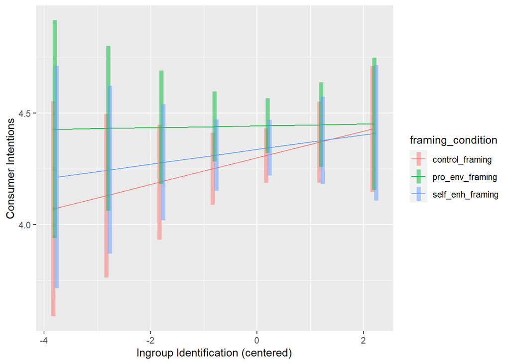

```r
# On a single graph
at_list <- list(ingroup_identification_center = seq(-3.8, 2.6, by = 1))

emmip(full_model_1a, framing_condition ~ ingroup_identification_center, at = at_list, CIs = TRUE, xlab = "Ingroup Identification (centered)", ylab = "Consumer Intentions")
```

Is the slope of the relationship between ingroup idenitification & consumer intentions stronger in any one of the framing conditions compared to the others?

```r
emtrends(full_model_1a, pairwise~framing_condition, var = "ingroup_identification_center", adjust = "none")
```

```
## $emtrends
##  framing_condition ingroup_identification_center.trend     SE  df lower.CL
##  control_framing                               0.05973 0.0611 883  -0.0602
##  pro_env_framing                               0.00402 0.0631 883  -0.1198
##  self_enh_framing                              0.03289 0.0644 883  -0.0935
##  upper.CL
##     0.180
##     0.128
##     0.159
##
## Results are averaged over the levels of: norm_condition, Gender
## Confidence level used: 0.95
##
## $contrasts
##  contrast                           estimate     SE  df t.ratio p.value
##  control_framing - pro_env_framing    0.0557 0.0874 883   0.638  0.5239
##  control_framing - self_enh_framing   0.0268 0.0885 883   0.303  0.7618
##  pro_env_framing - self_enh_framing  -0.0289 0.0897 883  -0.322  0.7476
##
## Results are averaged over the levels of: norm_condition, Gender
```

> > Exploratory RQ1: Is there a three-way interaction between ingroup identification, framing, and norm condition?

Third, interaction between ingroup identification, framing, & norm condition:

```r
emtrends(full_model_1a, ~norm_condition | framing_condition, var = "ingroup_identification_center", adjust = "tukey")
```

```
## framing_condition = control_framing:
##  norm_condition   ingroup_identification_center.trend    SE  df lower.CL
##  control_norm                                 0.19629 0.123 883   -0.120
##  descriptive_norm                             0.05362 0.171 883   -0.386
##  convention_norm                             -0.05192 0.148 883   -0.434
##  social_norm                                  0.00924 0.112 883   -0.278
##  moral_norm                                   0.09143 0.119 883   -0.215
##  upper.CL
##    0.5121
##    0.4930
##    0.3302
##    0.2968
##    0.3975
##
## framing_condition = pro_env_framing:
##  norm_condition   ingroup_identification_center.trend    SE  df lower.CL
##  control_norm                                 0.01011 0.138 883   -0.345
##  descriptive_norm                             0.01153 0.136 883   -0.338
##  convention_norm                             -0.04400 0.137 883   -0.396
##  social_norm                                 -0.03253 0.141 883   -0.396
##  moral_norm                                   0.07501 0.150 883   -0.312
##  upper.CL
##    0.3647
##    0.3608
##    0.3083
##    0.3306
##    0.4616
##
## framing_condition = self_enh_framing:
##  norm_condition   ingroup_identification_center.trend    SE  df lower.CL
##  control_norm                                -0.10491 0.141 883   -0.469
##  descriptive_norm                             0.15633 0.123 883   -0.161
##  convention_norm                              0.21386 0.156 883   -0.187
##  social_norm                                  0.21612 0.150 883   -0.169
##  moral_norm                                  -0.31693 0.148 883   -0.697
##  upper.CL
##    0.2587
##    0.4735
##    0.6145
##    0.6013
##    0.0634
##
## Results are averaged over the levels of: Gender
## Confidence level used: 0.95
## Conf-level adjustment: sidak method for 5 estimates
```

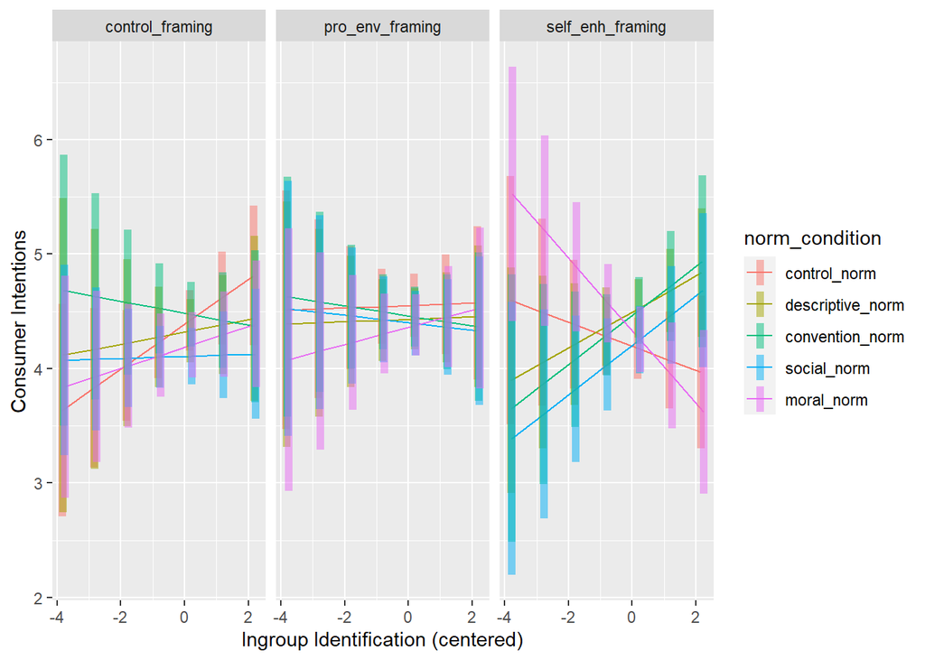

```r
# Separate graph for each framing condition
at_list <- list(ingroup_identification_center = seq(-3.8, 2.6, by = 1))

emmip(full_model_1a, norm_condition ~ ingroup_identification_center | framing_condition, at = at_list, CIs = TRUE, xlab = "Ingroup Identification (centered)", ylab = "Consumer Intentions")
```

### All cells compared to control

> > Exploratory RQ2: Which combination of framing and norm condition produced the strongest reductions in consumer intentions compared to the control condition?

```r
emmeans(full_model_1a, pairwise ~ norm_condition*framing_condition, adjust = "tukey")
```

```
## $emmeans
##  norm_condition   framing_condition emmean    SE  df lower.CL upper.CL
##  control_norm     control_framing     4.39 0.131 883     4.13     4.64
##  descriptive_norm control_framing     4.32 0.145 883     4.04     4.61
##  convention_norm  control_framing     4.48 0.145 883     4.20     4.77
##  social_norm      control_framing     4.11 0.120 883     3.87     4.35
##  moral_norm       control_framing     4.19 0.146 883     3.90     4.48
##  control_norm     pro_env_framing     4.55 0.136 883     4.28     4.82
##  descriptive_norm pro_env_framing     4.43 0.135 883     4.17     4.70
##  convention_norm  pro_env_framing     4.46 0.129 883     4.21     4.71
##  social_norm      pro_env_framing     4.40 0.143 883     4.12     4.68
##  moral_norm       pro_env_framing     4.37 0.132 883     4.11     4.63
##  control_norm     self_enh_framing    4.20 0.133 883     3.94     4.46
##  descriptive_norm self_enh_framing    4.50 0.131 883     4.24     4.76
##  convention_norm  self_enh_framing    4.47 0.142 883     4.19     4.75
##  social_norm      self_enh_framing    4.22 0.151 883     3.92     4.51
##  moral_norm       self_enh_framing    4.31 0.140 883     4.04     4.58
##
## Results are averaged over the levels of: Gender
## Confidence level used: 0.95
##
## $contrasts
##  contrast                                                             estimate
##  control_norm control_framing - descriptive_norm control_framing       0.06477
##  control_norm control_framing - convention_norm control_framing       -0.09684
##  control_norm control_framing - social_norm control_framing            0.27838
##  control_norm control_framing - moral_norm control_framing             0.19563
##  control_norm control_framing - control_norm pro_env_framing          -0.16454
##  control_norm control_framing - descriptive_norm pro_env_framing      -0.04554
##  control_norm control_framing - convention_norm pro_env_framing       -0.07238
##  control_norm control_framing - social_norm pro_env_framing           -0.01383
##  control_norm control_framing - moral_norm pro_env_framing             0.02046
##  control_norm control_framing - control_norm self_enh_framing          0.18995
##  control_norm control_framing - descriptive_norm self_enh_framing     -0.11111
##  control_norm control_framing - convention_norm self_enh_framing      -0.08401
##  control_norm control_framing - social_norm self_enh_framing           0.17165
##  control_norm control_framing - moral_norm self_enh_framing            0.07734
##  descriptive_norm control_framing - convention_norm control_framing   -0.16161
##  descriptive_norm control_framing - social_norm control_framing        0.21361
##  descriptive_norm control_framing - moral_norm control_framing         0.13086
```

[output cut: 182 more lines]

```
##  0.200 883   0.757  1.0000
##  0.192 883   0.296  1.0000
##  0.186 883  -1.621  0.9541
##  0.194 883  -1.413  0.9861
##  0.201 883  -0.091  1.0000
##  0.193 883  -0.584  1.0000
##  0.192 883   0.141  1.0000
##  0.200 883   1.417  0.9858
##  0.192 883   0.982  0.9997
##  0.206 883   1.239  0.9962
##  0.200 883   0.809  1.0000
##  0.206 883  -0.458  1.0000
##
## Results are averaged over the levels of: Gender
## P value adjustment: tukey method for comparing a family of 15 estimates
```

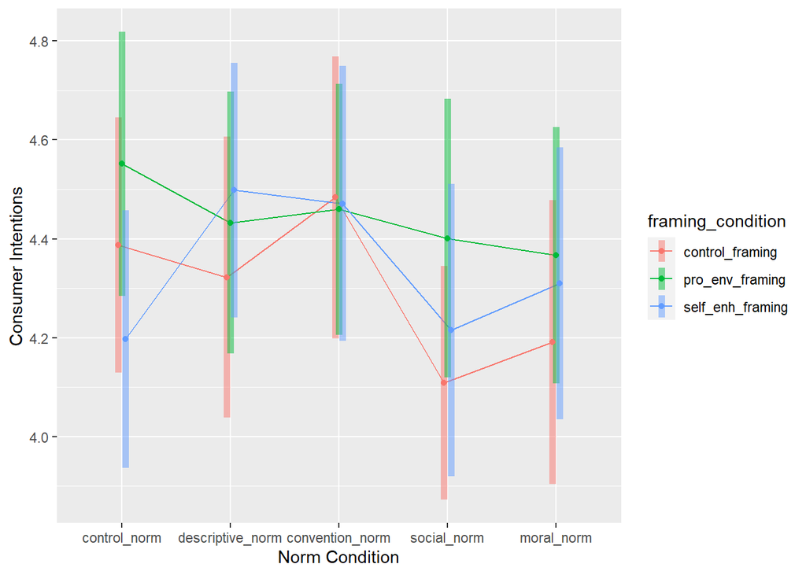

```r
emmip(full_model_1a, framing_condition ~ norm_condition, CIs = TRUE, xlab = "Norm Condition", ylab = "Consumer Intentions")
```

There are no significant differences between the control norm/control framing condition and any of the other combinations of framing/norm conditions.

### Gender Interactions (exploratory)

Three-way Gender Interactions:

```r
emmeans(full_model_1a, ~ norm_condition*Gender*framing_condition, adjust = "none")
```

```
##  norm_condition   Gender framing_condition emmean    SE  df lower.CL upper.CL
##  control_norm     Woman  control_framing     4.43 0.135 883     4.17     4.70
##  descriptive_norm Woman  control_framing     4.37 0.147 883     4.08     4.66
##  convention_norm  Woman  control_framing     4.53 0.150 883     4.24     4.82
##  social_norm      Woman  control_framing     4.15 0.124 883     3.91     4.40
##  moral_norm       Woman  control_framing     4.24 0.151 883     3.94     4.53
##  control_norm     Man    control_framing     4.34 0.140 883     4.07     4.62
##  descriptive_norm Man    control_framing     4.28 0.154 883     3.98     4.58
##  convention_norm  Man    control_framing     4.44 0.152 883     4.14     4.74
##  social_norm      Man    control_framing     4.06 0.130 883     3.81     4.32
##  moral_norm       Man    control_framing     4.15 0.153 883     3.85     4.45
##  control_norm     Woman  pro_env_framing     4.60 0.140 883     4.32     4.87
##  descriptive_norm Woman  pro_env_framing     4.48 0.140 883     4.20     4.75
##  convention_norm  Woman  pro_env_framing     4.50 0.132 883     4.24     4.76
##  social_norm      Woman  pro_env_framing     4.45 0.145 883     4.16     4.73
##  moral_norm       Woman  pro_env_framing     4.41 0.133 883     4.15     4.67
##  control_norm     Man    pro_env_framing     4.51 0.143 883     4.23     4.79
##  descriptive_norm Man    pro_env_framing     4.39 0.142 883     4.11     4.67
##  convention_norm  Man    pro_env_framing     4.41 0.138 883     4.14     4.69
##  social_norm      Man    pro_env_framing     4.36 0.153 883     4.05     4.66
##  moral_norm       Man    pro_env_framing     4.32 0.143 883     4.04     4.60
##  control_norm     Woman  self_enh_framing    4.24 0.135 883     3.98     4.51
##  descriptive_norm Woman  self_enh_framing    4.54 0.134 883     4.28     4.81
##  convention_norm  Woman  self_enh_framing    4.52 0.146 883     4.23     4.80
##  social_norm      Woman  self_enh_framing    4.26 0.154 883     3.96     4.56
##  moral_norm       Woman  self_enh_framing    4.35 0.145 883     4.07     4.64
##  control_norm     Man    self_enh_framing    4.15 0.143 883     3.87     4.43
##  descriptive_norm Man    self_enh_framing    4.45 0.141 883     4.18     4.73
##  convention_norm  Man    self_enh_framing    4.43 0.149 883     4.13     4.72
##  social_norm      Man    self_enh_framing    4.17 0.158 883     3.86     4.48
##  moral_norm       Man    self_enh_framing    4.26 0.147 883     3.98     4.55
##
## Confidence level used: 0.95
```

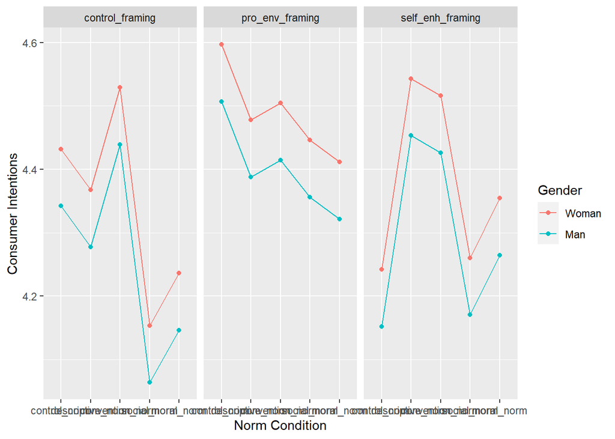

```r
emmip(full_model_1a, Gender ~ norm_condition | framing_condition, CIs = FALSE, xlab = "Norm Condition", ylab = "Consumer Intentions")
```

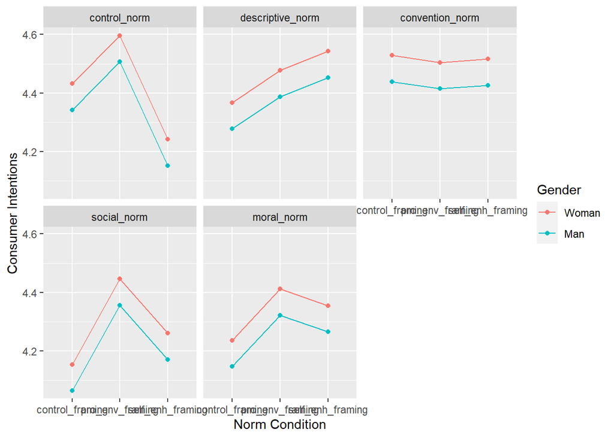

```r
emmip(full_model_1a, Gender ~ framing_condition | norm_condition, CIs = FALSE, xlab = "Norm Condition", ylab = "Consumer Intentions")
```

# Logistic Analysis (DV = Consumer Behaviors)

Consumer Behaviors:

- 0 = New Clothing
- 1 = Secondhand Clothing

## Running Model

```r
log_model <- glm(consumer_behaviors ~ framing_condition*norm_condition*biospheric_center + framing_condition*norm_condition*altruistic_center + framing_condition*norm_condition*egoistic_center + framing_condition*norm_condition*hedonic_center + framing_condition*norm_condition*ingroup_identification_center + socially_desirable_center + clothing_interest_center + Gender + Age_center, data = data_R, family = "binomial")
```

## Model Summary

### ANOVA Output

```r
anova(log_model) %>%
  knitr::kable(digits = 3)
```

|  | Df | Deviance | Resid. Df | Resid. Dev |
| --- | --- | --- | --- | --- |
| NULL | NA | NA | 961 | 1324.019 |
| framing_condition | 2 | 5.673 | 959 | 1318.346 |
| norm_condition | 4 | 0.633 | 955 | 1317.713 |
| biospheric_center | 1 | 31.475 | 954 | 1286.238 |
| altruistic_center | 1 | 0.192 | 953 | 1286.046 |
| egoistic_center | 1 | 74.482 | 952 | 1211.564 |
| hedonic_center | 1 | 0.280 | 951 | 1211.284 |
| ingroup_identification_center | 1 | 1.020 | 950 | 1210.265 |
| socially_desirable_center | 1 | 21.812 | 949 | 1188.453 |
| clothing_interest_center | 1 | 0.608 | 948 | 1187.845 |
| Gender | 1 | 0.032 | 947 | 1187.813 |
| Age_center | 1 | 5.416 | 946 | 1182.397 |
| framing_condition:norm_condition | 8 | 2.925 | 938 | 1179.471 |
| framing_condition:biospheric_center | 2 | 0.833 | 936 | 1178.639 |
| norm_condition:biospheric_center | 4 | 3.474 | 932 | 1175.165 |
| framing_condition:altruistic_center | 2 | 4.556 | 930 | 1170.608 |
| norm_condition:altruistic_center | 4 | 5.710 | 926 | 1164.899 |
| framing_condition:egoistic_center | 2 | 3.784 | 924 | 1161.115 |
| norm_condition:egoistic_center | 4 | 1.661 | 920 | 1159.454 |
| framing_condition:hedonic_center | 2 | 1.780 | 918 | 1157.674 |
| norm_condition:hedonic_center | 4 | 4.482 | 914 | 1153.192 |
| framing_condition:ingroup_identification_center | 2 | 0.811 | 912 | 1152.381 |
| norm_condition:ingroup_identification_center | 4 | 1.432 | 908 | 1150.950 |
| framing_condition:norm_condition:biospheric_center | 8 | 6.187 | 900 | 1144.763 |
| framing_condition:norm_condition:altruistic_center | 8 | 13.006 | 892 | 1131.757 |
| framing_condition:norm_condition:egoistic_center | 8 | 4.181 | 884 | 1127.576 |
| framing_condition:norm_condition:hedonic_center | 8 | 7.804 | 876 | 1119.773 |
| framing_condition:norm_condition:ingroup_identification_center | 8 | 4.709 | 868 | 1115.063 |

### Regression Summary

- 171 observations deleted due to missingness

```r
log_summ$coefficients %>%
  knitr::kable(digits = c(2, 2, 2, 3))
```

|  | Estimate | Std. Error | z value | Pr(>\|z\|) |
| --- | --- | --- | --- | --- |
| (Intercept) | -0.18 | 0.08 | -2.21 | 0.027 |
| framing_conditionFrameCode1 | 0.13 | 0.19 | 0.69 | 0.489 |
| framing_conditionFrameCode2 | 0.50 | 0.17 | 2.98 | 0.003 |
| norm_condition1 | 0.17 | 0.12 | 1.39 | 0.166 |
| norm_condition2 | 0.00 | 0.07 | -0.05 | 0.964 |
| norm_condition3 | 0.00 | 0.05 | -0.05 | 0.956 |
| norm_condition4 | 0.01 | 0.04 | 0.28 | 0.777 |
| biospheric_center | 0.46 | 0.12 | 3.93 | 0.000 |
| altruistic_center | 0.28 | 0.16 | 1.69 | 0.092 |
| egoistic_center | -0.81 | 0.11 | -7.17 | 0.000 |
| hedonic_center | -0.02 | 0.13 | -0.16 | 0.877 |
| ingroup_identification_center | 0.06 | 0.08 | 0.78 | 0.436 |
| socially_desirable_center | -0.51 | 0.12 | -4.28 | 0.000 |
| clothing_interest_center | 0.05 | 0.10 | 0.52 | 0.603 |
| Gender1 | 0.07 | 0.18 | 0.38 | 0.706 |
| Age_center | -0.11 | 0.05 | -2.29 | 0.022 |
| framing_conditionFrameCode1:norm_condition1 | 0.30 | 0.29 | 1.02 | 0.309 |
| framing_conditionFrameCode2:norm_condition1 | 0.34 | 0.27 | 1.25 | 0.211 |
| framing_conditionFrameCode1:norm_condition2 | -0.09 | 0.17 | -0.53 | 0.593 |
| framing_conditionFrameCode2:norm_condition2 | -0.07 | 0.15 | -0.48 | 0.633 |
| framing_conditionFrameCode1:norm_condition3 | 0.08 | 0.12 | 0.71 | 0.479 |
| framing_conditionFrameCode2:norm_condition3 | 0.05 | 0.11 | 0.50 | 0.615 |
| framing_conditionFrameCode1:norm_condition4 | 0.02 | 0.10 | 0.25 | 0.805 |
| framing_conditionFrameCode2:norm_condition4 | -0.03 | 0.08 | -0.42 | 0.677 |
| framing_conditionFrameCode1:biospheric_center | -0.19 | 0.30 | -0.65 | 0.518 |
| framing_conditionFrameCode2:biospheric_center | 0.53 | 0.24 | 2.25 | 0.025 |
| norm_condition1:biospheric_center | 0.24 | 0.18 | 1.37 | 0.170 |
| norm_condition2:biospheric_center | 0.01 | 0.10 | 0.09 | 0.932 |
| norm_condition3:biospheric_center | 0.00 | 0.07 | 0.04 | 0.972 |
| norm_condition4:biospheric_center | 0.00 | 0.06 | 0.06 | 0.955 |

[output cut: 64 more lines]

```r
#tab_model(log_model, p.style = "numeric_stars", transform = NULL)
```

### Odds Ratios

Converting log odds estimates to odds ratios:

```r
exp(coef(log_model)) %>%
  knitr::kable(digits = 2)
```

|  | x |
| --- | --- |
| (Intercept) | 0.84 |
| framing_conditionFrameCode1 | 1.14 |
| framing_conditionFrameCode2 | 1.65 |
| norm_condition1 | 1.19 |
| norm_condition2 | 1.00 |
| norm_condition3 | 1.00 |
| norm_condition4 | 1.01 |
| biospheric_center | 1.58 |
| altruistic_center | 1.32 |
| egoistic_center | 0.44 |
| hedonic_center | 0.98 |
| ingroup_identification_center | 1.07 |
| socially_desirable_center | 0.60 |
| clothing_interest_center | 1.06 |
| Gender1 | 1.07 |
| Age_center | 0.89 |
| framing_conditionFrameCode1:norm_condition1 | 1.34 |
| framing_conditionFrameCode2:norm_condition1 | 1.40 |
| framing_conditionFrameCode1:norm_condition2 | 0.91 |
| framing_conditionFrameCode2:norm_condition2 | 0.93 |
| framing_conditionFrameCode1:norm_condition3 | 1.09 |
| framing_conditionFrameCode2:norm_condition3 | 1.06 |
| framing_conditionFrameCode1:norm_condition4 | 1.02 |
| framing_conditionFrameCode2:norm_condition4 | 0.97 |
| framing_conditionFrameCode1:biospheric_center | 0.83 |
| framing_conditionFrameCode2:biospheric_center | 1.70 |
| norm_condition1:biospheric_center | 1.27 |
| norm_condition2:biospheric_center | 1.01 |
| norm_condition3:biospheric_center | 1.00 |
| norm_condition4:biospheric_center | 1.00 |

[output cut: 64 more lines]

```r
# with CIs
#exp(cbind(OR = coef(log_model), confint(log_model))) %>%
  #knitr::kable(digits = 2)
```

## Assessing Overall Effects

Effect of framing condition

```r
wald.test(b = coef(log_model), Sigma = vcov(log_model), Terms = 2:3)
```

```
## Wald test:
## ----------
##
## Chi-squared test:
## X2 = 9.4, df = 2, P(> X2) = 0.009
```

```r
wald.test(b = coef(log_model), Sigma = vcov(log_model), Terms = 4:7)
```

```
## Wald test:
## ----------
##
## Chi-squared test:
## X2 = 2.0, df = 4, P(> X2) = 0.73
```

Framing X Norm Interaction

```r
wald.test(b = coef(log_model), Sigma = vcov(log_model), Terms = 17:24)
```

```
## Wald test:
## ----------
##
## Chi-squared test:
## X2 = 4.1, df = 8, P(> X2) = 0.85
```

Framing X Biospheric Interaction

```r
wald.test(b = coef(log_model), Sigma = vcov(log_model), Terms = 25:26)
```

```
## Wald test:
## ----------
##
## Chi-squared test:
## X2 = 5.4, df = 2, P(> X2) = 0.066
```

Norm X Biospheric Interaction

```r
wald.test(b = coef(log_model), Sigma = vcov(log_model), Terms = 27:30)
```

```
## Wald test:
## ----------
##
## Chi-squared test:
## X2 = 2.0, df = 4, P(> X2) = 0.74
```

## Simple Effects

### Framing Condition

> > H1: Consumer intentions/behaviors will be lower in the self-enhancing framing than in the pro-environmental or control framing conditions.

```r
# on the log odds scale
emmeans(log_model, pairwise ~ framing_condition, adjust = "none")
```

```
## $emmeans
##  framing_condition emmean    SE  df asymp.LCL asymp.UCL
##  control_framing   -0.432 0.133 Inf    -0.692   -0.1714
##  pro_env_framing    0.119 0.138 Inf    -0.151    0.3887
##  self_enh_framing  -0.323 0.136 Inf    -0.590   -0.0564
##
## Results are averaged over the levels of: norm_condition, Gender
## Results are given on the logit (not the response) scale.
## Confidence level used: 0.95
##
## $contrasts
##  contrast                           estimate    SE  df z.ratio p.value
##  control_framing - pro_env_framing    -0.550 0.190 Inf  -2.899  0.0037
##  control_framing - self_enh_framing   -0.109 0.188 Inf  -0.577  0.5638
##  pro_env_framing - self_enh_framing    0.442 0.192 Inf   2.303  0.0213
##
## Results are averaged over the levels of: norm_condition, Gender
## Results are given on the log odds ratio (not the response) scale.
```

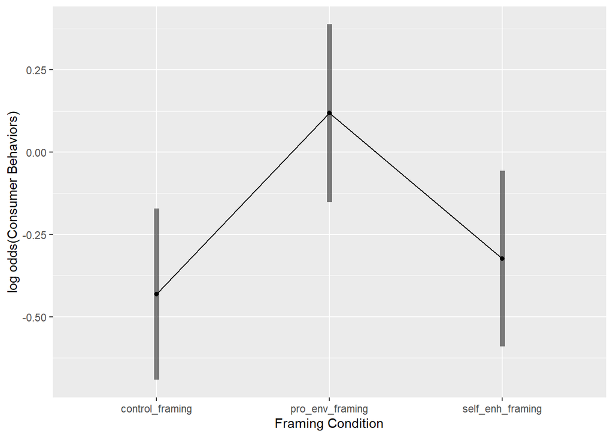

```r
emmip(log_model, ~ framing_condition, CIs = TRUE, xlab = "Framing Condition", ylab = "log odds(Consumer Behaviors)")
```

```r
# using probabilities
emmeans(log_model, pairwise ~ framing_condition, adjust = "none", regrid = "response")
```

```
## $emmeans
##  framing_condition  prob     SE  df asymp.LCL asymp.UCL
##  control_framing   0.394 0.0317 Inf     0.332     0.456
##  pro_env_framing   0.529 0.0336 Inf     0.463     0.595
##  self_enh_framing  0.420 0.0329 Inf     0.356     0.485
##
## Results are averaged over the levels of: norm_condition, Gender
## Confidence level used: 0.95
##
## $contrasts
##  contrast                           estimate     SE  df z.ratio p.value
##  control_framing - pro_env_framing   -0.1349 0.0458 Inf  -2.944  0.0032
##  control_framing - self_enh_framing  -0.0263 0.0452 Inf  -0.582  0.5608
##  pro_env_framing - self_enh_framing   0.1086 0.0466 Inf   2.330  0.0198
##
## Results are averaged over the levels of: norm_condition, Gender
```

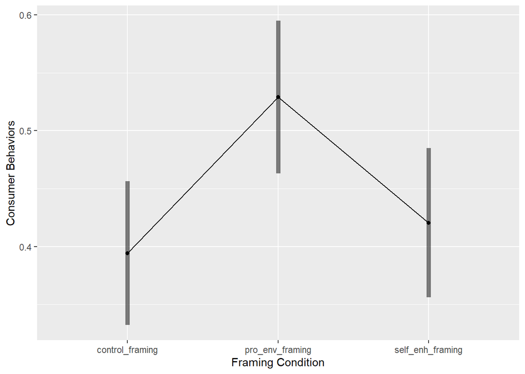

```r
emmip(log_model, ~ framing_condition, CIs = TRUE, regrid = "response", xlab = "Framing Condition", ylab = "Consumer Behaviors")
```

### Norm Condition

> > H2: Consumer intentions/behaviors will be lower in each norm condition compared to the control norm condition.

```r
# on the log odds scale
emmeans(log_model, pairwise ~ norm_condition, adjust = "none")
```

```
## $emmeans
##  norm_condition    emmean    SE  df asymp.LCL asymp.UCL
##  control_norm     -0.3880 0.171 Inf    -0.723   -0.0527
##  descriptive_norm -0.0373 0.177 Inf    -0.385    0.3104
##  convention_norm  -0.2310 0.173 Inf    -0.570    0.1078
##  social_norm      -0.2246 0.174 Inf    -0.566    0.1166
##  moral_norm       -0.1790 0.176 Inf    -0.523    0.1652
##
## Results are averaged over the levels of: framing_condition, Gender
## Results are given on the logit (not the response) scale.
## Confidence level used: 0.95
##
## $contrasts
##  contrast                           estimate    SE  df z.ratio p.value
##  control_norm - descriptive_norm    -0.35079 0.245 Inf  -1.430  0.1527
##  control_norm - convention_norm     -0.15705 0.242 Inf  -0.650  0.5159
##  control_norm - social_norm         -0.16344 0.241 Inf  -0.677  0.4984
##  control_norm - moral_norm          -0.20908 0.244 Inf  -0.858  0.3909
##  descriptive_norm - convention_norm  0.19374 0.247 Inf   0.785  0.4323
##  descriptive_norm - social_norm      0.18735 0.247 Inf   0.758  0.4483
##  descriptive_norm - moral_norm       0.14171 0.249 Inf   0.570  0.5686
##  convention_norm - social_norm      -0.00639 0.244 Inf  -0.026  0.9791
##  convention_norm - moral_norm       -0.05203 0.246 Inf  -0.212  0.8324
##  social_norm - moral_norm           -0.04564 0.246 Inf  -0.186  0.8525
##
## Results are averaged over the levels of: framing_condition, Gender
## Results are given on the log odds ratio (not the response) scale.
```

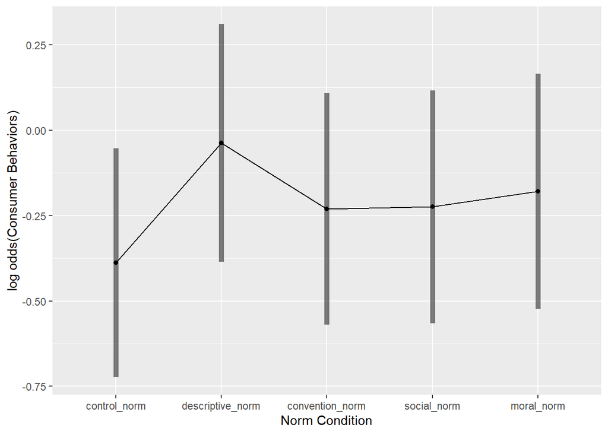

```r
emmip(log_model, ~ norm_condition, CIs = TRUE, xlab = "Norm Condition", ylab = "log odds(Consumer Behaviors)")
```

```r
# using probabilities
emmeans(log_model, pairwise ~ norm_condition, adjust = "none", regrid = "response")
```

```
## $emmeans
##  norm_condition    prob     SE  df asymp.LCL asymp.UCL
##  control_norm     0.405 0.0410 Inf     0.324     0.485
##  descriptive_norm 0.491 0.0421 Inf     0.408     0.573
##  convention_norm  0.443 0.0423 Inf     0.360     0.526
##  social_norm      0.446 0.0420 Inf     0.363     0.528
##  moral_norm       0.456 0.0430 Inf     0.371     0.540
##
## Results are averaged over the levels of: framing_condition, Gender
## Confidence level used: 0.95
##
## $contrasts
##  contrast                           estimate     SE  df z.ratio p.value
##  control_norm - descriptive_norm    -0.08590 0.0585 Inf  -1.469  0.1418
##  control_norm - convention_norm     -0.03827 0.0585 Inf  -0.654  0.5129
##  control_norm - social_norm         -0.04093 0.0580 Inf  -0.705  0.4807
##  control_norm - moral_norm          -0.05117 0.0591 Inf  -0.866  0.3864
##  descriptive_norm - convention_norm  0.04762 0.0594 Inf   0.802  0.4228
##  descriptive_norm - social_norm      0.04497 0.0591 Inf   0.761  0.4467
##  descriptive_norm - moral_norm       0.03473 0.0600 Inf   0.579  0.5625
##  convention_norm - social_norm      -0.00265 0.0592 Inf  -0.045  0.9642
##  convention_norm - moral_norm       -0.01290 0.0602 Inf  -0.214  0.8303
##  social_norm - moral_norm           -0.01025 0.0597 Inf  -0.172  0.8638
##
## Results are averaged over the levels of: framing_condition, Gender
```

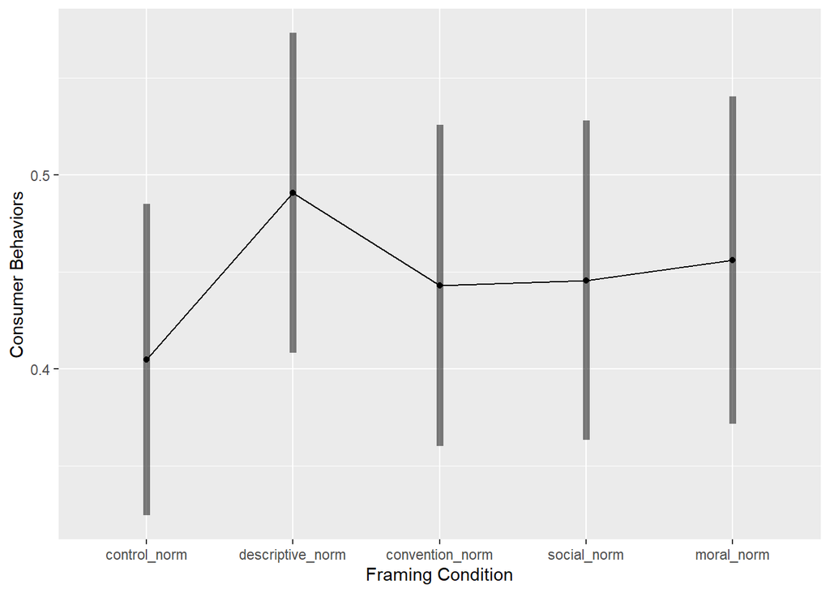

```r
emmip(log_model, ~ norm_condition, CIs = TRUE, regrid = "response", xlab = "Framing Condition", ylab = "Consumer Behaviors")
```

### Framing X Norm

> > H3: There will be a two-way interaction between framing & norm condition such that the effect of each norm will be stronger in the self-enhancing framing than in the pro-environmental or control framing conditions.

```r
# on the log odds scale
emmeans(log_model, pairwise ~ norm_condition | framing_condition, adjust = "none")
```

```
## $emmeans
## framing_condition = control_framing:
##  norm_condition     emmean    SE  df asymp.LCL asymp.UCL
##  control_norm     -0.33939 0.283 Inf    -0.893    0.2144
##  descriptive_norm -0.51020 0.301 Inf    -1.101    0.0805
##  convention_norm  -0.26255 0.304 Inf    -0.858    0.3330
##  social_norm      -0.62697 0.258 Inf    -1.133   -0.1214
##  moral_norm       -0.41886 0.323 Inf    -1.051    0.2137
##
## framing_condition = pro_env_framing:
##  norm_condition     emmean    SE  df asymp.LCL asymp.UCL
##  control_norm     -0.25336 0.292 Inf    -0.825    0.3181
##  descriptive_norm  0.54013 0.349 Inf    -0.144    1.2243
##  convention_norm  -0.00321 0.275 Inf    -0.543    0.5366
##  social_norm       0.23505 0.315 Inf    -0.383    0.8532
##  moral_norm        0.07507 0.293 Inf    -0.498    0.6485
##
## framing_condition = self_enh_framing:
##  norm_condition     emmean    SE  df asymp.LCL asymp.UCL
##  control_norm     -0.57138 0.309 Inf    -1.177    0.0342
##  descriptive_norm -0.14168 0.269 Inf    -0.668    0.3847
##  convention_norm  -0.42723 0.315 Inf    -1.045    0.1909
##  social_norm      -0.28188 0.322 Inf    -0.913    0.3494
##  moral_norm       -0.19309 0.294 Inf    -0.769    0.3826
##
## Results are averaged over the levels of: Gender
## Results are given on the logit (not the response) scale.
## Confidence level used: 0.95
##
## $contrasts
## framing_condition = control_framing:
##  contrast                           estimate    SE  df z.ratio p.value
##  control_norm - descriptive_norm      0.1708 0.412 Inf   0.415  0.6785
##  control_norm - convention_norm      -0.0768 0.415 Inf  -0.185  0.8530
##  control_norm - social_norm           0.2876 0.381 Inf   0.755  0.4503
##  control_norm - moral_norm            0.0795 0.429 Inf   0.185  0.8530
##  descriptive_norm - convention_norm  -0.2477 0.427 Inf  -0.580  0.5618
##  descriptive_norm - social_norm       0.1168 0.394 Inf   0.296  0.7670
##  descriptive_norm - moral_norm       -0.0913 0.441 Inf  -0.207  0.8359
##  convention_norm - social_norm        0.3644 0.398 Inf   0.917  0.3593
```

[output cut: 16 more lines]

```
## framing_condition = self_enh_framing:
##  contrast                           estimate    SE  df z.ratio p.value
##  control_norm - descriptive_norm     -0.4297 0.407 Inf  -1.055  0.2916
##  control_norm - convention_norm      -0.1442 0.440 Inf  -0.327  0.7434
##  control_norm - social_norm          -0.2895 0.445 Inf  -0.650  0.5155
##  control_norm - moral_norm           -0.3783 0.425 Inf  -0.889  0.3739
##  descriptive_norm - convention_norm   0.2855 0.412 Inf   0.694  0.4880
##  descriptive_norm - social_norm       0.1402 0.419 Inf   0.335  0.7380
##  descriptive_norm - moral_norm        0.0514 0.399 Inf   0.129  0.8974
##  convention_norm - social_norm       -0.1453 0.450 Inf  -0.323  0.7468
##  convention_norm - moral_norm        -0.2341 0.432 Inf  -0.542  0.5881
##  social_norm - moral_norm            -0.0888 0.436 Inf  -0.204  0.8385
##
## Results are averaged over the levels of: Gender
## Results are given on the log odds ratio (not the response) scale.
```

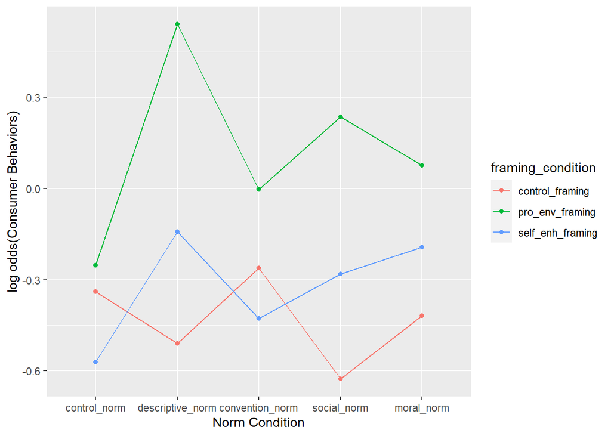

```r
emmip(log_model, framing_condition ~ norm_condition, CIs = FALSE, xlab = "Norm Condition", ylab = "log odds(Consumer Behaviors)")
```

```r
# using probabilities
emmeans(log_model, pairwise ~ norm_condition | framing_condition, adjust = "none", regrid = "response")
```

```
## $emmeans
## framing_condition = control_framing:
##  norm_condition    prob     SE  df asymp.LCL asymp.UCL
##  control_norm     0.416 0.0686 Inf     0.281     0.551
##  descriptive_norm 0.375 0.0706 Inf     0.237     0.514
##  convention_norm  0.435 0.0747 Inf     0.288     0.581
##  social_norm      0.348 0.0585 Inf     0.233     0.463
##  moral_norm       0.397 0.0772 Inf     0.245     0.548
##
## framing_condition = pro_env_framing:
##  norm_condition    prob     SE  df asymp.LCL asymp.UCL
##  control_norm     0.437 0.0717 Inf     0.296     0.578
##  descriptive_norm 0.632 0.0812 Inf     0.473     0.791
##  convention_norm  0.499 0.0688 Inf     0.364     0.634
##  social_norm      0.558 0.0777 Inf     0.406     0.711
##  moral_norm       0.519 0.0730 Inf     0.376     0.662
##
## framing_condition = self_enh_framing:
##  norm_condition    prob     SE  df asymp.LCL asymp.UCL
##  control_norm     0.361 0.0713 Inf     0.221     0.501
##  descriptive_norm 0.465 0.0668 Inf     0.334     0.596
##  convention_norm  0.395 0.0753 Inf     0.247     0.542
##  social_norm      0.430 0.0789 Inf     0.275     0.585
##  moral_norm       0.452 0.0727 Inf     0.309     0.594
##
## Results are averaged over the levels of: Gender
## Confidence level used: 0.95
##
## $contrasts
## framing_condition = control_framing:
##  contrast                           estimate     SE  df z.ratio p.value
##  control_norm - descriptive_norm      0.0408 0.0982 Inf   0.415  0.6778
##  control_norm - convention_norm      -0.0188 0.1013 Inf  -0.185  0.8530
##  control_norm - social_norm           0.0677 0.0898 Inf   0.754  0.4507
##  control_norm - moral_norm            0.0192 0.1033 Inf   0.186  0.8528
##  descriptive_norm - convention_norm  -0.0596 0.1025 Inf  -0.581  0.5611
##  descriptive_norm - social_norm       0.0269 0.0911 Inf   0.296  0.7675
##  descriptive_norm - moral_norm       -0.0216 0.1045 Inf  -0.207  0.8360
##  convention_norm - social_norm        0.0865 0.0946 Inf   0.914  0.3605
##  convention_norm - moral_norm         0.0379 0.1074 Inf   0.353  0.7240
```

[output cut: 14 more lines]

```
##
## framing_condition = self_enh_framing:
##  contrast                           estimate     SE  df z.ratio p.value
##  control_norm - descriptive_norm     -0.1037 0.0972 Inf  -1.067  0.2861
##  control_norm - convention_norm      -0.0339 0.1034 Inf  -0.327  0.7433
##  control_norm - social_norm          -0.0691 0.1061 Inf  -0.651  0.5149
##  control_norm - moral_norm           -0.0909 0.1016 Inf  -0.895  0.3709
##  descriptive_norm - convention_norm   0.0698 0.1001 Inf   0.698  0.4853
##  descriptive_norm - social_norm       0.0346 0.1033 Inf   0.335  0.7374
##  descriptive_norm - moral_norm        0.0128 0.0989 Inf   0.129  0.8974
##  convention_norm - social_norm       -0.0352 0.1090 Inf  -0.323  0.7467
##  convention_norm - moral_norm        -0.0571 0.1050 Inf  -0.543  0.5869
##  social_norm - moral_norm            -0.0219 0.1073 Inf  -0.204  0.8384
##
## Results are averaged over the levels of: Gender
```

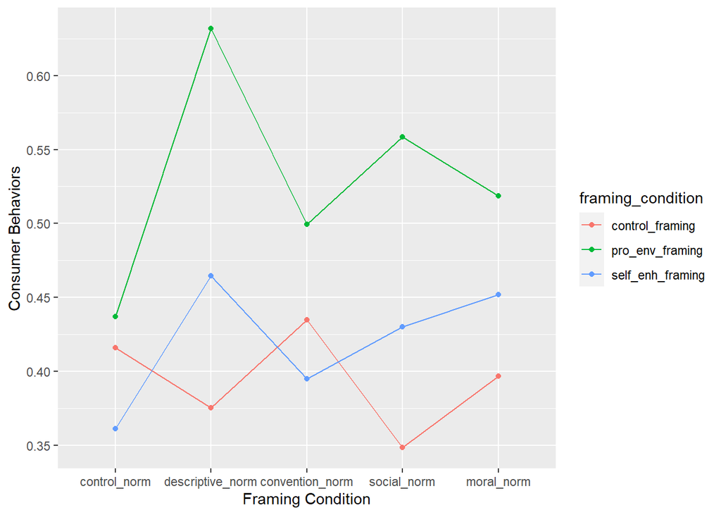

```r
emmip(log_model, framing_condition ~ norm_condition, CIs = FALSE, regrid = "response", xlab = "Framing Condition", ylab = "Consumer Behaviors")
```